# Data Management

Cassandra Bayer

7/25/2018

# Setting the Environment

Before I start my work, I run a global `Controller` file wherein I house my libraries, custom functions, and global options. This allows me to continue my work unimpeded.

```r
setwd("/Users/cassandrabayer/Desktop/Estimating-Treatment-Effects")
options("scipen" =100, "digits" = 4)

# Load Packages -----------------------------------------------------------
# load basic packages
library(data.table)
library(tidyr)
library(tidyverse)
```

```r
# visualization packages
library(ggplot2)
library(plotly)
library(corrplot)
library(stargazer)
# stats and prediction
library(stats)
library(forecast)
#library(fpp2)
library(tseries)
library(Hmisc)
library(MatchIt)
# Model Selection/Validation
library(MASS)
library(glmnet)
library(car)
library(ROCR)
library(pscl)
library(rpart)

#Dates
library(zoo)
library(lubridate)
# Text analysis
library(RSiteCatalyst)
library(RTextTools)
# spell check
sorted_words <- names(sort(table(strsplit(tolower(paste(readLines("http://www.norvig.com/big.txt"), collapse = " ")), "[^a-z]+")), decreasing = TRUE))
# correct <- function(word) { c(sorted_words[ adist(word, sorted_words) <= min(adist(word, sorted_words), 2)], word)[1] }
library(qdap)
#devtools::install_github("ropensci/spelling")

# Load any custom functions -----------------------------------------------
rowShift <- function(x, shiftLen = 1L) {
  r <- (1L + shiftLen):(length(x) + shiftLen)
  r[r<1] <- NA
  return(x[r])
}

shift <- function(x, offset = 1, pad = NA) {
  r <- (1 + offset):(length(x) + offset)
  r[r<1] <- NA
  ans <- x[r]
  ans[is.na(ans)] <- pad
  return(ans)
}

maxMissing <- function(x){
  if(all(is.na(x))){
    return(NA_real_)
  } else{
    return(max(x, na.rm = T))
  }
}

nwords <- function(string, pseudo=F){
  ifelse( pseudo,
          pattern <- "\\S+",
          pattern <- "[[:alpha:]]+"
  )
  str_count(string, pattern)
}

wordParser <- function(word){
  unlist(lapply(seq(nchar(word)), function(x) substr(word, x, x)))
}
```

# Pre-Processing

Initially I load the data and convert to data.tables. I use the `data.table` package as it is much more performant. As a first pass, I look at the data types of each of columns in each of the tables. Finding that the dates are coded as characters, I coerce them to the data.type `date`, which allows me to manipulate them as if they were integers.

```r
# Load data  --------------------------------------------------------------
# Inital loading and basic cleaning
case <- as.data.table(read.csv("case.csv", stringsAsFactors = F))
demo <- as.data.table(read.csv("demo.csv",stringsAsFactors = F))
priorArrests <- as.data.table(read.csv("prior_arrests.csv", stringsAsFactors = F))

# Pre-processing/cleaning -------------------------------------------------------------------------------
## Get names and data types for all in environment
sapply(case, class)
```

```
##      caseid   person_id arrest_date dispos_date       treat
##   "integer"   "integer" "character" "character"   "integer"
```

```r
sapply(demo, class)
```

```
##   person_id        race      gender       bdate
##   "integer" "character" "character" "character"
```

```r
sapply(priorArrests, class)
```

```
##   person_id arrest_date
##   "integer" "character"
```

```r
## Update data types
case[ , c("arrest_date", "dispos_date") := lapply(.SD, as.Date), .SDcols = c("arrest_date", "dispos_date")]
demo[, bdate := as.Date(bdate)]
priorArrests[, arrest_date := as.Date(arrest_date)]
```

# Merges and Reshaping

Next, I tailor the data structure to what I want it to be. While I want the `case` data to drive the shape of the table, I still need information from the `priorArrest` data to glean if a person has had more arrests outside of what’s included in the case. To do so, I create `caseSmall`, which is unique to the `person_id` and `arrest_date` level. Once I have that subsetted data table, I then `rbind` it onto the full `priorArrests`, which is already unique to the same level. The bind allows me to have a full data set of arrest dates by person. This will come in handy later when I need to calculate the number of prior arrests for each current arrest.  
Since I have what I need from the `priorArrest` data in a self-contained table, I then merge the `demo` data onto the `case` data and order it by `person_id`-`arrest_date` combination, which creates the `full` data I then will be working with. Once I do a quick check for missing data (and luckily there is none), I am free to move on.

```r
## Merge 1: Get a comprehensive list of all arrests by person
caseSmall <- case[, .(person_id, arrest_date)]
totalArrests <- unique(rbind(caseSmall, priorArrests))
totalArrests <- totalArrests[order(person_id, arrest_date)]

## Merge 2: demo/case data together
setkey(case, person_id)
setkey(demo, person_id)
full <- demo[case]
full <- full[order(person_id, arrest_date)]

## Look for completeness of data before proceeding
sapply(full,function(x) sum(is.na(x)))
```

```
##   person_id        race      gender       bdate      caseid arrest_date
##           0           0           0           0           0           0
## dispos_date       treat
##           0           0
```

# Part 1: Data Management

## Question 1

In order to create `re_arrest`, I need to find out whether a person was arrested in between their most recent arrest and their disposition date. To do so, I first find the total number of arrests, `totalArrests`, that a person has within the `case` data. I then look for where a person has been arrested more than once (since this parameter does not apply to those who have only been arrested once and ineligible to be assigned with the `re_arrest` flag), and where there `arrest_date` is less then the `arrest_date` directly below it (using the `shift` function), and look where the below `arrest_date` is also less than the `dispos_date`. The `data.table` package is a boon in this process as it operates row-by-row. Since the data is already ordered by date, I make this operation perform based on groupings by `person_id` which ensures that the calculations are done by unique arrestee.  
I do a quick check by looking at all `person_id`s that have any flags for `re_arrest`. A handful of records show me that the calculation was performed properly.

```r
full[, totalArrests := as.integer(uniqueN(arrest_date)), by = person_id]
full <- full[, re_arrest := 0]
full[totalArrests > 1 &
       (arrest_date < shift(arrest_date, 1) &
          shift(arrest_date, 1) < dispos_date),
     re_arrest := 1, by = person_id]

## Check my work
re_arrests <- full[re_arrest==1, unique(person_id)]
full[person_id %in% re_arrests]
```

```
##        person_id     race gender      bdate caseid arrest_date dispos_date
##     1:         8    BLACK      M 1978-04-04   2913  2012-10-06  2013-12-29
##     2:         8    BLACK      M 1978-04-04   6304  2013-04-06  2013-07-07
##     3:        13    BLACK      M 1963-04-27  88153  2012-10-29  2013-01-21
##     4:        13    BLACK      M 1963-04-27  40377  2012-11-04  2013-03-05
##     5:        13    BLACK      M 1963-04-27  39447  2013-07-31  2013-08-16
##    ---
## 11925:     19983 HISPANIC      M 1967-11-16  14837  2013-07-01  2013-09-24
## 11926:     19987 HISPANIC      M 1972-08-28  12170  2012-03-01  2013-10-18
## 11927:     19987 HISPANIC      M 1972-08-28  92133  2012-03-27  2012-04-03
## 11928:     19988    WHITE      M 1973-05-02  80147  2012-11-03  2014-02-09
## 11929:     19988    WHITE      M 1973-05-02   2301  2013-04-25  2014-05-19
##        treat totalArrests re_arrest
##     1:     1            2         1
##     2:     0            2         0
##     3:     1            3         1
##     4:     1            3         0
##     5:     1            3         0
##    ---
## 11925:     1            3         0
## 11926:     0            2         1
## 11927:     1            2         0
## 11928:     1            2         1
## 11929:     0            2         0
```

## Question 2

To generate `prior_requests`, I use the subsetted data table `totalArrests` table generated earlier. I first create an index that itemizes the records, generates a cumulative sum of that index, and subtracts one to denote the number of prior arrests per current arrest. Once I generate that figure, I drop the index, and merge the the `prior_arrest` variable onto the `full` data set. I set the `person_id` and `arrest_date` as the merge key to ensure that the number of prior arrests is aligned to the proper record.

```r
totalArrests[, index := 1]
totalArrests[, prior_arrests := cumsum(index)-1, by = person_id]
totalArrests[, index := NULL]
setkey(totalArrests, person_id, arrest_date)
setkey(full, person_id, arrest_date)
full <- totalArrests[full]
```

## Question 3

Since I have already converted the data type and ordered the data, all I have to do is simply substract the `bdate` from the `arrest_date` to get the age of the defendant at the time of each arrest. The date automatically calculates this figure in days, so once I divide by 365 and round to the nearest whole number, the age variable is in a useful format.  
While I do group the age calculation by `person_id`, the `by` parameter is actually not necessary here given the nature of by row calculations in data.table, but it helps to elucidate the intention of the calculation.

```r
full[, age := arrest_date - bdate, by = person_id]
full[, age := as.integer(age)]
full[, age := round((age/365),0)]
```

# Quick Look at Distribution

Before moving on, I want to know if there is an even distribution amongst those who have received the treatment. To do so, I generate some quick tabs to look at the break down of age, race, and gender. While this output it helpful, I also would like to *see* how the data spreads. I find that age is pretty well distributed, but there is more skew in race. A predominant number of defendants in the sample are black males.  
I also want to get a quick glance at the correlatons between variables. A correlation matrix shows me that there are no surprising or meaninful correlations outside the obvious (`arrest_date` and `dispos_date`).

```r
# Quick distributions
full[, .N, by = race]
```

```
##        race     N
## 1: HISPANIC  6221
## 2:    BLACK 15126
## 3:    ASIAN  1239
## 4:    WHITE  2414
```

```r
full[, .N, by = gender]
```

```
##    gender     N
## 1:      F  4936
## 2:      M 20064
```

```r
full[, .N, by = age][order(age)]
```

```
##     age    N
##  1:  10    4
##  2:  11    7
##  3:  12   16
##  4:  13   25
##  5:  14   78
##  6:  15  118
##  7:  16  177
##  8:  17  205
##  9:  18  339
## 10:  19  459
## 11:  20  561
## 12:  21  635
## 13:  22  811
## 14:  23 1063
```

[output cut: 47 more lines]

```r
summary(full$age)
```

```
##    Min. 1st Qu.  Median    Mean 3rd Qu.    Max.
##    10.0    25.0    30.0    30.7    36.0    70.0
```

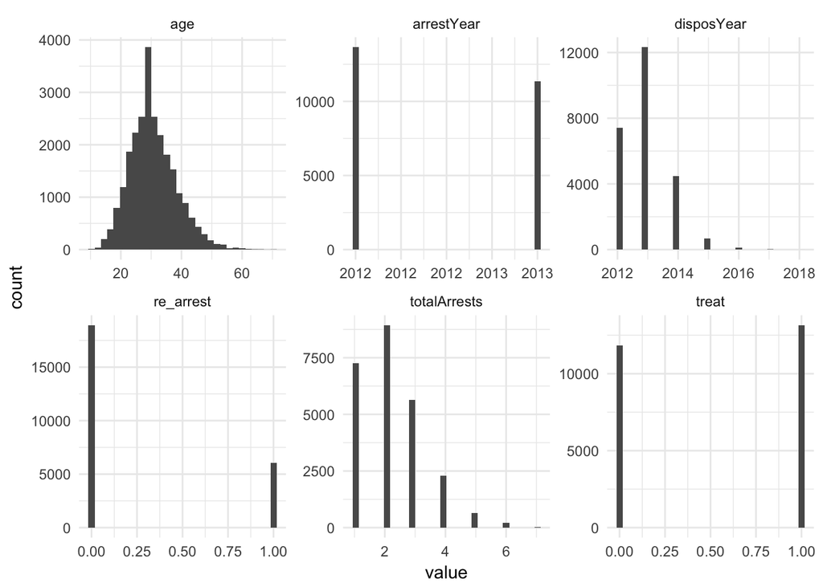

```r
# struncture the date for plotting
toPlot <- full[, .(arrestYear = year(arrest_date),
                   race = as.factor(race),
                   gender = as.factor(gender),
                   disposYear = year(dispos_date),
                   treat, totalArrests, re_arrest, age)]

# Plots with facet wrapping
toPlot %>%
  keep(is.numeric) %>%
  gather() %>%
  ggplot(aes(value)) +
  facet_wrap(~ key, scales = "free") +
  geom_histogram() + theme_minimal()
```

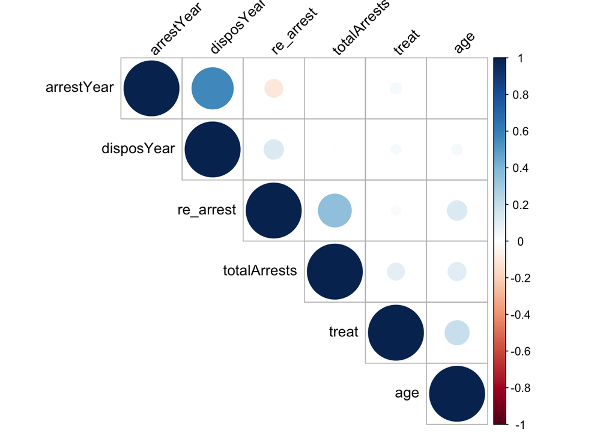

```r
corData <- cor(toPlot[,.(arrestYear,
                         disposYear,
                         treat,
                         re_arrest,
                         totalArrests,age)])

corrplot(corData,
         type = "upper",
         order = "hclust",
         tl.col = "black",
         tl.srt = 45)
```

# Part II: Statistical Analysis

Before diving in, I reset categorical variables to factors and then drop the ID and date variables since they will not be useful in any models.  
Once cleaned up, I can then partition the data into training and test sets. I randomly select 75% of my data as the `train` and then use the remaining data as my `test`. While I could simply select rows, I want to ensure true randomness in my selection. To ensure completeness of the data, I do a quick check to make sure that the sum of the train and test rows are equal to the original data set.

```r
# new col and snapshot
full[, anyReArrest := max(re_arrest), by = person_id]
fullRaw <- full # keep a raw copy before manipulating

# clean up
full[,`:=`(race = as.factor(race),
            gender = as.factor(gender))]
full <- full[, .SD, .SDcols = !grepl(x = names(full),pattern =  "id|date")]

## split data
trainData<- floor(0.75 * nrow(full))
set.seed(8675309)
trainData <- sample(seq_len(nrow(full)), size = trainData)
train <-full[trainData]
test <- full[-trainData]
nrow(train) + nrow(test) == nrow(full) # gut check
```

```
## [1] TRUE
```

## Model selection

### Why a logistical regression?

I chose a logistical regression for a few reasons: * My dependent variable is binary * I am assessing the impact of the treatment, not necessarily trying to predict what causes `re_arrest` * By using a step wise model selection, I can see variable-by-variable the impact on the model and thus the incrememntal decrease in explanatory power of treat * The model allows me to understand if the treatment is explaining variation in `re_arrests` or if other independent variables are explaining it.

### Model Applicaton

The first model that I run is the basic y ~ x: the effect of `treat` on `re_arrests`. A simple correlation shows me a decently low positive relationship, which already seems suspect. This correlation nods to the fact that treatment is associated with a greater probability of getting arrested again prior to disposition.

## Model 1

When I run the basic model, `lm`, I find that the relationship is highly significant, but I sense there is a lot of noise in the model.

```r
# logit regression
## 1) Simple model to look at relationship between treatment and re_arrest
cor(x = train$treat, y = train$re_arrest)
```

```
## [1] 0.03079
```

```r
lm <- glm(formula = re_arrest ~ treat,
          data = train,
          family = binomial(link = 'logit'))

summary(lm)
```

```
##
## Call:
## glm(formula = re_arrest ~ treat, family = binomial(link = "logit"),
##     data = train)
##
## Deviance Residuals:
##    Min      1Q  Median      3Q     Max
## -0.772  -0.772  -0.725  -0.725   1.712
##
## Coefficients:
##             Estimate Std. Error z value             Pr(>|z|)
## (Intercept)  -1.2022     0.0252  -47.73 < 0.0000000000000002 ***
## treat         0.1438     0.0341    4.21             0.000025 ***
## ---
## Signif. codes:  0 '***' 0.001 '**' 0.01 '*' 0.05 '.' 0.1 ' ' 1
##
## (Dispersion parameter for binomial family taken to be 1)
##
##     Null deviance: 20882  on 18749  degrees of freedom
## Residual deviance: 20864  on 18748  degrees of freedom
## AIC: 20868
##
## Number of Fisher Scoring iterations: 4
```

## Model 2

```r
# 2) Full model with all vars --------------------------------------------------------------------------
lmFull <- glm(formula = re_arrest ~ .,
              data = train,
              family = binomial(link = 'logit'))

summary(lmFull)
```

```
##
## Call:
## glm(formula = re_arrest ~ ., family = binomial(link = "logit"),
##     data = train)
##
## Deviance Residuals:
##     Min       1Q   Median       3Q      Max
## -1.7272  -0.0001  -0.0001  -0.0001   1.8774
##
## Coefficients:
##                Estimate Std. Error z value            Pr(>|z|)
## (Intercept)   -20.32322  107.71945   -0.19                0.85
## prior_arrests  -0.24265    0.01427  -17.01 <0.0000000000000002 ***
## raceBLACK       0.04764    0.09958    0.48                0.63
## raceHISPANIC    0.01519    0.10499    0.14                0.88
## raceWHITE      -0.10100    0.11779   -0.86                0.39
## genderM         0.00848    0.05520    0.15                0.88
## treat          -0.04621    0.04550   -1.02                0.31
## totalArrests    0.03228    0.02290    1.41                0.16
## age             0.04774    0.00366   13.04 <0.0000000000000002 ***
## anyReArrest    19.86240  107.71936    0.18                0.85
## ---
## Signif. codes:  0 '***' 0.001 '**' 0.01 '*' 0.05 '.' 0.1 ' ' 1
##
## (Dispersion parameter for binomial family taken to be 1)
##
##     Null deviance: 20882  on 18749  degrees of freedom
## Residual deviance: 12101  on 18740  degrees of freedom
## AIC: 12121
##
## Number of Fisher Scoring iterations: 18
```

## Model 3

Once I’ve run the fullest and sparsest models, I use the stepwise model selection process. `stepAIC` chooses the highest quality model avaiable within your data by estimating the bias-variance tradeoff of each model. The model that it chooses only selects the variables of significance and discards the others to do away with noise.

```r
# Step-wise ---------------------------------------------------------------------------------------------
## model that returns the lowest deviance in the AIC
lmStep <- stepAIC(lmFull, direction = "both",
                  trace = T)
```

```
## Start:  AIC=12121
## re_arrest ~ prior_arrests + race + gender + treat + totalArrests +
##     age + anyReArrest
##
##                 Df Deviance   AIC
## - gender         1    12101 12119
## - race           3    12105 12119
## - treat          1    12102 12120
## - totalArrests   1    12103 12121
## <none>                12101 12121
## - age            1    12276 12294
## - prior_arrests  1    12405 12423
## - anyReArrest    1    18265 18283
##
## Step:  AIC=12119
## re_arrest ~ prior_arrests + race + treat + totalArrests + age +
##     anyReArrest
##
##                 Df Deviance   AIC
## - race           3    12105 12117
## - treat          1    12102 12118
## - totalArrests   1    12103 12119
## <none>                12101 12119
## + gender         1    12101 12121
## - age            1    12276 12292
## - prior_arrests  1    12405 12421
## - anyReArrest    1    18267 18283
##
## Step:  AIC=12117
## re_arrest ~ prior_arrests + treat + totalArrests + age + anyReArrest
##
##                 Df Deviance   AIC
## - treat          1    12106 12116
## - totalArrests   1    12107 12117
## <none>                12105 12117
## + race           3    12101 12119
## + gender         1    12105 12119
## - age            1    12279 12289
## - prior_arrests  1    12408 12418
## - anyReArrest    1    18274 18284
```

[output cut: 11 more lines]

```
## - prior_arrests  1    12433 12441
## - anyReArrest    1    18276 18284
##
## Step:  AIC=12116
## re_arrest ~ prior_arrests + age + anyReArrest
##
##                 Df Deviance   AIC
## <none>                12108 12116
## + totalArrests   1    12106 12116
## + treat          1    12107 12117
## + gender         1    12108 12118
## + race           3    12104 12118
## - age            1    12282 12288
## - prior_arrests  1    12443 12449
## - anyReArrest    1    20441 20447
```

```r
summary(lmStep)
```

```
##
## Call:
## glm(formula = re_arrest ~ prior_arrests + age + anyReArrest,
##     family = binomial(link = "logit"), data = train)
##
## Deviance Residuals:
##     Min       1Q   Median       3Q      Max
## -1.7329  -0.0001  -0.0001  -0.0001   1.9024
##
## Coefficients:
##                Estimate Std. Error z value            Pr(>|z|)
## (Intercept)   -20.24019  107.74745   -0.19                0.85
## prior_arrests  -0.24060    0.01353  -17.78 <0.0000000000000002 ***
## age             0.04671    0.00359   13.01 <0.0000000000000002 ***
## anyReArrest    19.90136  107.74742    0.18                0.85
## ---
## Signif. codes:  0 '***' 0.001 '**' 0.01 '*' 0.05 '.' 0.1 ' ' 1
##
## (Dispersion parameter for binomial family taken to be 1)
##
##     Null deviance: 20882  on 18749  degrees of freedom
## Residual deviance: 12108  on 18746  degrees of freedom
## AIC: 12116
##
## Number of Fisher Scoring iterations: 18
```

## Model 4

```r
full2 <- full #snapshot
full2[, `:=`(age2 = age^20,
             priorArrests2 = prior_arrests^2,
             agePriorArrests = age*prior_arrests)]

train2 <- full[1:(.75*nrow(full))]
test2 <- full[(nrow(train)+1):nrow(full)]
nrow(train2) + nrow(test2) == nrow(full)
```

```
## [1] TRUE
```

```r
lmFull2 <- glm(formula = re_arrest ~ .,
               data = train2,
               family = binomial(link = 'logit'))
summary(lmFull2)
```

```
##
## Call:
## glm(formula = re_arrest ~ ., family = binomial(link = "logit"),
##     data = train2)
##
## Deviance Residuals:
##     Min       1Q   Median       3Q      Max
## -1.6536  -0.0001  -0.0001  -0.0001   2.3069
##
## Coefficients:
##                                                    Estimate
## (Intercept)     -20.077401739617339870846990379504859447479
## prior_arrests    -0.157416939396000876705272730760043486953
## raceBLACK         0.015424424853648152980434282710575644160
## raceHISPANIC      0.012520087556050253640993474846254684962
## raceWHITE        -0.136827202715282342238012347479525487870
## genderM           0.008033435804685939637947988956057088217
## treat            -0.042369306965862732483607544509141007438
## totalArrests      0.039341997347624391156983847395167686045
## age               0.025729611649575087617414226315304404125
## anyReArrest      19.795318856157599896050669485703110694885
## age2             -0.000000000000000000000000000000000000118
## priorArrests2    -0.025288768607028708212958179046836448833
## agePriorArrests   0.004894435371759630823418341094566130778
##                                                  Std. Error z value
## (Intercept)     108.361814347061709895569947548210620880127   -0.19
## prior_arrests     0.039705403474358226534324245449170120992   -3.96
## raceBLACK         0.100567121342676688011685826040775282308    0.15
## raceHISPANIC      0.106011920748610544151802059786859899759    0.12
## raceWHITE         0.118167809947957655469785720470099477097   -1.16
## genderM           0.054532287879749313797006493587105069309    0.15
## treat             0.045612983981102230013338072467377060093   -0.93
## totalArrests      0.023058987087375543839629088438414328266    1.71
## age               0.009181488183546164180692805700800818158    2.80
## anyReArrest     108.361553230815502502082381397485733032227    0.18
## age2              0.000000000000000000000000000000000000114   -1.03
## priorArrests2     0.005548378336612514415138175394304198562   -4.56
## agePriorArrests   0.001698589067897110591737197538009240816    2.88
##                  Pr(>|z|)
## (Intercept)        0.8530
## prior_arrests   0.0000735 ***
## raceBLACK          0.8781
## raceHISPANIC       0.9060
## raceWHITE          0.2469
## genderM            0.8829
## treat              0.3529
## totalArrests       0.0880 .
## age                0.0051 **
## anyReArrest        0.8551
## age2               0.3016
## priorArrests2   0.0000052 ***
## agePriorArrests    0.0040 **
## ---
## Signif. codes:  0 '***' 0.001 '**' 0.01 '*' 0.05 '.' 0.1 ' ' 1
##
## (Dispersion parameter for binomial family taken to be 1)
##
##     Null deviance: 20909  on 18749  degrees of freedom
## Residual deviance: 12137  on 18737  degrees of freedom
## AIC: 12163
##
## Number of Fisher Scoring iterations: 18
```

```r
lmStep2 <- stepAIC(lmFull2, direction = "both",
                   trace = T)
```

```
## Start:  AIC=12163
## re_arrest ~ prior_arrests + race + gender + treat + totalArrests +
##     age + anyReArrest + age2 + priorArrests2 + agePriorArrests
##
##                   Df Deviance   AIC
## - gender           1    12137 12161
## - race             3    12141 12161
## - treat            1    12138 12162
## - age2             1    12138 12162
## <none>                  12137 12163
## - totalArrests     1    12140 12164
## - age              1    12145 12169
## - agePriorArrests  1    12145 12169
## - prior_arrests    1    12152 12176
## - priorArrests2    1    12158 12182
## - anyReArrest      1    18020 18044
##
## Step:  AIC=12161
## re_arrest ~ prior_arrests + race + treat + totalArrests + age +
##     anyReArrest + age2 + priorArrests2 + agePriorArrests
##
##                   Df Deviance   AIC
## - race             3    12141 12159
## - treat            1    12138 12160
## - age2             1    12138 12160
## <none>                  12137 12161
## - totalArrests     1    12140 12162
## + gender           1    12137 12163
## - age              1    12145 12167
## - agePriorArrests  1    12145 12167
## - prior_arrests    1    12152 12174
## - priorArrests2    1    12158 12180
## - anyReArrest      1    18024 18046
##
## Step:  AIC=12159
## re_arrest ~ prior_arrests + treat + totalArrests + age + anyReArrest +
##     age2 + priorArrests2 + agePriorArrests
##
##                   Df Deviance   AIC
## - treat            1    12142 12158
```

[output cut: 29 more lines]

```
## re_arrest ~ prior_arrests + totalArrests + age + anyReArrest +
##     priorArrests2 + agePriorArrests
##
##                   Df Deviance   AIC
## <none>                  12143 12157
## - totalArrests     1    12146 12158
## + age2             1    12142 12158
## + treat            1    12142 12158
## + race             3    12139 12159
## + gender           1    12143 12159
## - agePriorArrests  1    12151 12163
## - age              1    12152 12164
## - prior_arrests    1    12159 12171
## - priorArrests2    1    12163 12175
## - anyReArrest      1    18039 18051
```

```r
summary(lmStep2)
```

```
##
## Call:
## glm(formula = re_arrest ~ prior_arrests + totalArrests + age +
##     anyReArrest + priorArrests2 + agePriorArrests, family = binomial(link = "logit"),
##     data = train2)
##
## Deviance Residuals:
##     Min       1Q   Median       3Q      Max
## -1.6699  -0.0001  -0.0001  -0.0001   2.2936
##
## Coefficients:
##                  Estimate Std. Error z value  Pr(>|z|)
## (Intercept)     -20.11374  108.37903   -0.19    0.8528
## prior_arrests    -0.15325    0.03812   -4.02 0.0000582 ***
## totalArrests      0.03626    0.02299    1.58    0.1148
## age               0.02738    0.00890    3.08    0.0021 **
## anyReArrest      19.79921  108.37884    0.18    0.8550
## priorArrests2    -0.02429    0.00548   -4.43 0.0000092 ***
## agePriorArrests   0.00442    0.00161    2.75    0.0060 **
## ---
## Signif. codes:  0 '***' 0.001 '**' 0.01 '*' 0.05 '.' 0.1 ' ' 1
##
## (Dispersion parameter for binomial family taken to be 1)
##
##     Null deviance: 20909  on 18749  degrees of freedom
## Residual deviance: 12143  on 18743  degrees of freedom
## AIC: 12157
##
## Number of Fisher Scoring iterations: 18
```

# Model Validation

## McFadden’s and Chi-Squared Tests as a gut check

```r
# McFadden's R-Squared
pR2(lmStep)
```

```
##         llh     llhNull          G2    McFadden        r2ML        r2CU
##  -6053.7659 -10440.9400   8774.3482      0.4202      0.3737      0.5564
```

```r
pR2(lmStep2)
```

```
##         llh     llhNull          G2    McFadden        r2ML        r2CU
##  -6071.5146 -10454.4205   8765.8118      0.4192      0.3734      0.5556
```

```r
# Assess the deviance between our model and the null model
anova(lmStep, test = "Chisq")
```

```
## Analysis of Deviance Table
##
## Model: binomial, link: logit
##
## Response: re_arrest
##
## Terms added sequentially (first to last)
##
##
##               Df Deviance Resid. Df Resid. Dev             Pr(>Chi)
## NULL                          18749      20882
## prior_arrests  1      424     18748      20458 < 0.0000000000000002 ***
## age            1       17     18747      20441              0.00004 ***
## anyReArrest    1     8333     18746      12108 < 0.0000000000000002 ***
## ---
## Signif. codes:  0 '***' 0.001 '**' 0.01 '*' 0.05 '.' 0.1 ' ' 1
```

```r
anova(lmStep2, test = "Chisq")
```

```
## Analysis of Deviance Table
##
## Model: binomial, link: logit
##
## Response: re_arrest
##
## Terms added sequentially (first to last)
##
##
##                 Df Deviance Resid. Df Resid. Dev             Pr(>Chi)
## NULL                            18749      20909
## prior_arrests    1      423     18748      20486 < 0.0000000000000002 ***
## totalArrests     1     1977     18747      18509 < 0.0000000000000002 ***
## age              1      224     18746      18285 < 0.0000000000000002 ***
## anyReArrest      1     6120     18745      12165 < 0.0000000000000002 ***
## priorArrests2    1       14     18744      12151              0.00014 ***
## agePriorArrests  1        8     18743      12143              0.00575 **
## ---
## Signif. codes:  0 '***' 0.001 '**' 0.01 '*' 0.05 '.' 0.1 ' ' 1
```

## Bringing in the test data

I now can apply my models to the test data to see how I’ve done. I find that the second model is more accurately, but very narrowly. The `predict` package is a succint way to calculate the errors and vectorize them to roll up the model’s accuracy.

```r
## Get probabilities for each obs that obs re_arrest = 1
lmStepProbs <- predict(lmStep,
                       newdata=test,
                       type='response')

lmStepProbs2 <- predict(lmStep2,
                        newdata=test2,
                        type='response')

## Convert probs > .5 to 1 and lower than .5 to 0
lmStepResults <- ifelse(lmStepProbs > 0.5,1,0)
lmStepResults2 <- ifelse(lmStepProbs2 > 0.5,1,0)

# Get our average
misClasificError <- mean(lmStepResults != test$re_arrest)
misClasificError2 <- mean(lmStepResults2 != test2$re_arrest)
```

```r
paste0('The accuracy for model w/o interaction vars is ',1-misClasificError,
                                'and the accuracy for model w/ interaction vars is ', 1-misClasificError2,
                                if(misClasificError < misClasificError2){'. Model 1 is more accurate.'}
                                else {'. Model 2 is more accurate.'})
```

```
## [1] "The accuracy for model w/o interaction vars is 0.80544and the accuracy for model w/ interaction vars is 0.80848. Model 2 is more accurate."
```

## Area under the ROC Curve

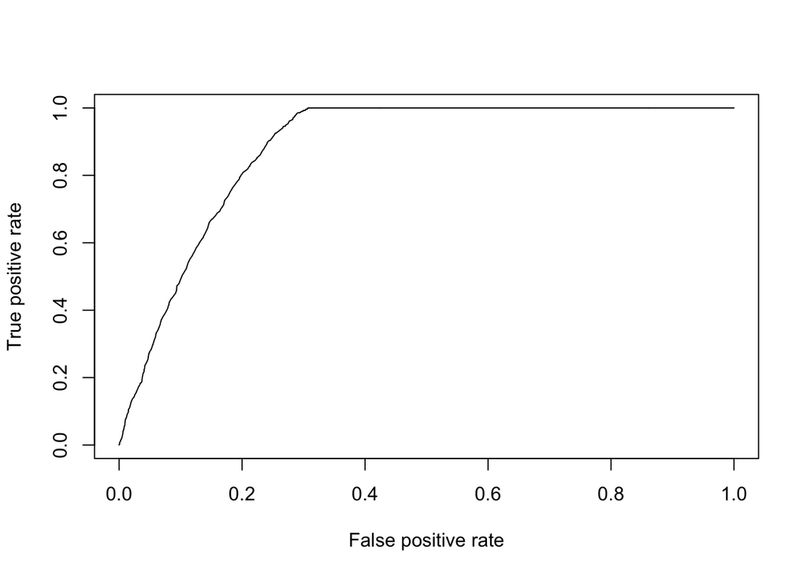

```r
prediction <- prediction(lmStepProbs, test$re_arrest)
performance <- performance(prediction, measure = "tpr", x.measure = "fpr")
plot(performance)
```

```r
auc <- performance(prediction, measure = "auc")
auc <- auc@y.values[[1]]
auc
```

```
## [1] 0.8829
```

# Thinking about Treatment Assignment

```r
# What if we changed the data? --------------------------------------------------------------------------
# Propensity score matching ----------------------------------------------------------------------------
pScores <- matchit(re_arrest ~ age + prior_arrests + treat,
                   data = full,
                   method = "nearest",
                   distance = "logit")

summary(pScores)
```

```
##
## Call:
## matchit(formula = re_arrest ~ age + prior_arrests + treat, data = full,
##     method = "nearest", distance = "logit")
##
## Summary of balance for all data:
##               Means Treated Means Control SD Control Mean Diff eQQ Med
## distance              0.261         0.237      0.067     0.024   0.024
## age                  32.405        30.106      7.580     2.299   2.000
## prior_arrests         4.372         3.609      2.126     0.763   1.000
## treat                 0.552         0.518      0.500     0.034   0.000
##               eQQ Mean eQQ Max
## distance         0.024   0.039
## age              2.300   6.000
## prior_arrests    0.764   1.000
## treat            0.034   1.000
##
##
## Summary of balance for matched data:
##               Means Treated Means Control SD Control Mean Diff eQQ Med
## distance              0.261         0.261      0.070     0.000       0
## age                  32.405        32.269      7.852     0.136       0
## prior_arrests         4.372         4.386      2.089    -0.013       0
## treat                 0.552         0.554      0.497    -0.002       0
##               eQQ Mean eQQ Max
## distance         0.000   0.031
## age              0.190   4.000
## prior_arrests    0.017   1.000
## treat            0.002   1.000
##
## Percent Balance Improvement:
##               Mean Diff. eQQ Med eQQ Mean eQQ Max
## distance           99.90     100    99.85   21.89
## age                94.06     100    91.73   33.33
## prior_arrests      98.25     100    97.74    0.00
## treat              95.20       0    95.19    0.00
##
## Sample sizes:
##           Control Treated
## All         18919    6081
## Matched      6081    6081
## Unmatched   12838       0
## Discarded       0       0
```

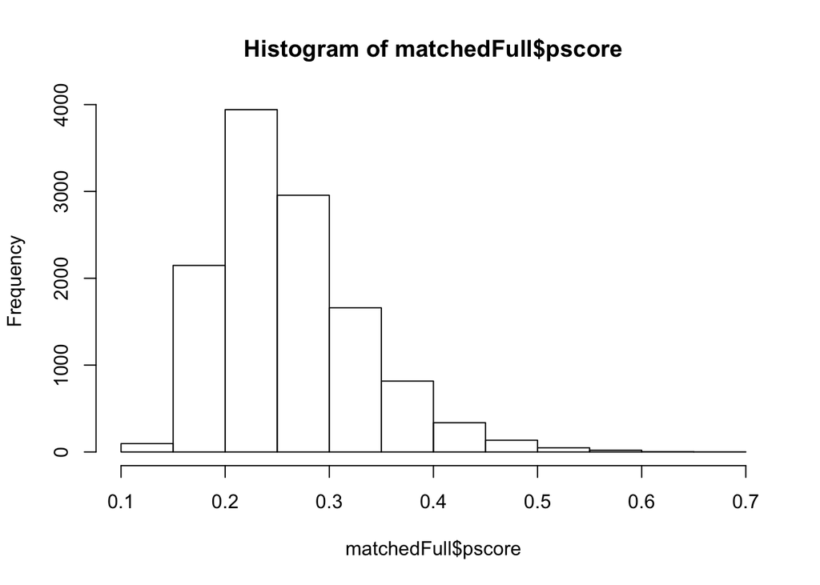

```r
## Keep only the matched data
matchedFull <- data.table(match.data(pScores, distance = "pscore"))
hist(matchedFull$pscore)
```

## Were the treatment groups balanced?

I use a t-test to see whether there is a significant difference in `re_arrest` rates for those who received the treatment adn those who did not. The first model, which is using unmatched data, shows that there is a highly significant difference. However, the magnitude of that significance drops in the second t-test using the matched data.  
These two differing tests suggest that any variation of `re_arrest` rates may not be as attributable to the treatment as one might think. Rather, the variance may be accounted for by non-random assignment, or systematic differences in people that received the treatment and those that did not.

```r
t.test(full[treat == 1]$re_arrest, full[treat == 0]$re_arrest, paired = F)
```

```
##
##  Welch Two Sample t-test
##
## data:  full[treat == 1]$re_arrest and full[treat == 0]$re_arrest
## t = 4.7, df = 25000, p-value = 0.000003
## alternative hypothesis: true difference in means is not equal to 0
## 95 percent confidence interval:
##  0.01466 0.03592
## sample estimates:
## mean of x mean of y
##    0.2552    0.2299
```

```r
t.test(matchedFull[treat==1]$re_arrest,matchedFull[treat==0]$re_arrest,paired = F)
```

```
##
##  Welch Two Sample t-test
##
## data:  matchedFull[treat == 1]$re_arrest and matchedFull[treat == 0]$re_arrest
## t = -0.18, df = 12000, p-value = 0.9
## alternative hypothesis: true difference in means is not equal to 0
## 95 percent confidence interval:
##  -0.01954  0.01621
## sample estimates:
## mean of x mean of y
##    0.4993    0.5009
```